# PCIT-CoS-Waitlist RCT Paper 1: DPICS Child Compliance

Nancy Briggs

2024-04-29

### DPICS Child Compliance

#### Descriptives

*Descriptives for Percentage of Effective Commands*

| group | time | n | mean | sd | median | min | max |
| --- | --- | --- | --- | --- | --- | --- | --- |
| 1 | 1 | 29 | 47.04606 | 14.87939 | 43.75000 | 20.000000 | 82.35294 |
| 1 | 2 | 21 | 53.00534 | 12.17461 | 54.54545 | 33.333333 | 75.00000 |
| 1 | 3 | 18 | 54.04649 | 24.98276 | 59.16667 | 10.000000 | 85.00000 |
| 2 | 1 | 29 | 46.62153 | 17.85624 | 42.10526 | 16.000000 | 78.57143 |
| 2 | 2 | 12 | 51.96127 | 25.29084 | 59.83982 | 9.756098 | 79.16667 |
| 2 | 3 | 5 | 65.40371 | 15.58984 | 65.51724 | 47.826087 | 88.88889 |
| 3 | 1 | 28 | 49.11532 | 13.84115 | 49.13793 | 25.000000 | 76.00000 |
| 3 | 2 | 22 | 49.80484 | 17.16227 | 46.17092 | 14.285714 | 79.41176 |
| 3 | 3 | 0 | NaN | NA | NA | Inf | -Inf |

Note:  
One person in the Waitlist group had a value at Follow Up. It was set to missing.

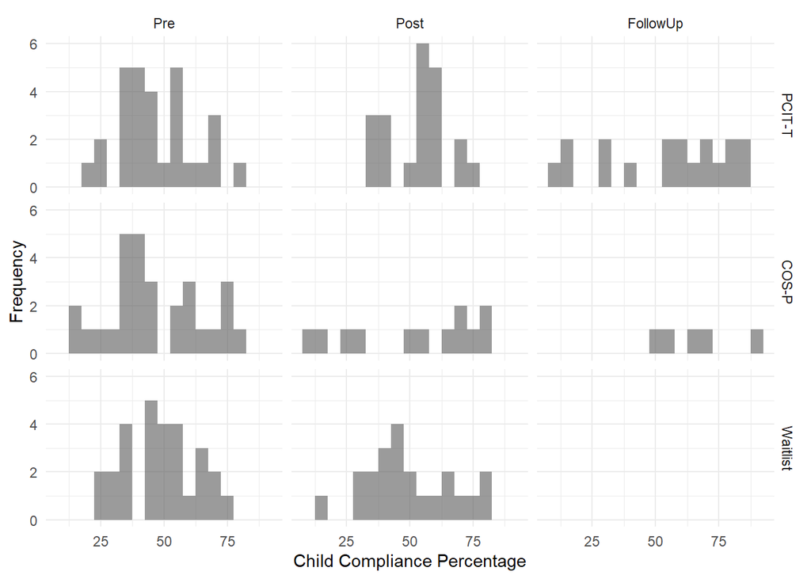

#### Model & Results

A generalized linear mixed model (GLMM) with random effect for individual and fixed effects of group, time and the interaction was run on the number of Compliance responses in the total number of verbalizations. A binomial distribution was specified with a logit link. Estimated marginal means were obtained, and contrasts specified to test Hypothesis 1 and Hypothesis 2. Assumptions on the residuals were examined using simulated residuals (see below).

TOTAL_eff_commands_TIME_1 is the denominator, and CHILD_CO_total_TIME_1 is the numerator

```
## fixed-effect model matrix is rank deficient so dropping 1 column / coefficient
```

This is the ANOVA table for the model. p-values are likelihood ratio tests for adding the new term to the model just before. A p-value <0.05 indicates that adding that term results in better model fit.

|  | Effect | npar | AIC | BIC | logLik | deviance | Chisq | Df | Pr(>Chisq) |
| --- | --- | --- | --- | --- | --- | --- | --- | --- | --- |
| result0 | Intercept | 2 | 985.2588 | 991.4585 | -490.6294 | 981.2588 | NA | NA | NA |
| result1 | Group | 4 | 988.9554 | 1001.3549 | -490.4777 | 980.9554 | 0.3033927 | 2 | 0.8592492 |
| result2 | Time | 6 | 987.9122 | 1006.5114 | -487.9561 | 975.9122 | 5.0431777 | 2 | 0.0803319 |
| result3 | Group*Time | 9 | 989.8034 | 1017.7022 | -485.9017 | 971.8034 | 4.1088840 | 3 | 0.2499441 |

```r
summary(result3)
```

```
## Generalized linear mixed model fit by maximum likelihood (Laplace
##   Approximation) [glmerMod]
##  Family: binomial  ( logit )
## Formula: cbind(co, effcommands - co) ~ group + time + group * time + (1 |
##     id)
##    Data: p
##
##      AIC      BIC   logLik deviance df.resid
##    989.8   1017.7   -485.9    971.8      155
##
## Scaled residuals:
##     Min      1Q  Median      3Q     Max
## -3.4159 -0.6971 -0.0701  0.7983  2.5804
##
## Random effects:
##  Groups Name        Variance Std.Dev.
##  id     (Intercept) 0.2591   0.5091
## Number of obs: 164, groups:  id, 88
##
## Fixed effects:
##              Estimate Std. Error z value Pr(>|z|)
## (Intercept)  -0.09684    0.12058  -0.803   0.4219
## group2       -0.03161    0.16998  -0.186   0.8525
## group3        0.07162    0.16807   0.426   0.6700
## time2         0.30520    0.13643   2.237   0.0253 *
## time3         0.20888    0.14371   1.454   0.1461
## group2:time2 -0.11448    0.19921  -0.575   0.5655
## group3:time2 -0.30643    0.17273  -1.774   0.0760 .
## group2:time3  0.16860    0.26451   0.637   0.5239
## ---
## Signif. codes:  0 '***' 0.001 '**' 0.01 '*' 0.05 '.' 0.1 ' ' 1
##
## Correlation of Fixed Effects:
##             (Intr) group2 group3 time2  time3  grp2:2 grp3:2
## group2      -0.709
## group3      -0.718  0.509
## time2       -0.363  0.257  0.261
## time3       -0.362  0.256  0.260  0.389
## group2:tim2  0.249 -0.315 -0.179 -0.684 -0.266
## group3:tim2  0.287 -0.203 -0.358 -0.791 -0.308  0.541
## group2:tim3  0.197 -0.242 -0.142 -0.213 -0.545  0.305  0.170
## fit warnings:
## fixed-effect model matrix is rank deficient so dropping 1 column / coefficient
```

#### Estimated Means & Change

Adjusted p-value from Bonferroni correction.

##### Group mean at each timepoint

Estimated Mean Number of LP

| Time | Group | Mean | SE | LowerCL | UpperCL |
| --- | --- | --- | --- | --- | --- |
| 1 | 1 | 0.476 | 0.030 | 0.417 | 0.535 |
| 2 | 1 | 0.552 | 0.036 | 0.481 | 0.621 |
| 3 | 1 | 0.528 | 0.037 | 0.454 | 0.600 |
| 1 | 2 | 0.468 | 0.030 | 0.410 | 0.527 |
| 2 | 2 | 0.516 | 0.040 | 0.437 | 0.594 |
| 3 | 2 | 0.562 | 0.057 | 0.448 | 0.669 |
| 1 | 3 | 0.494 | 0.029 | 0.437 | 0.551 |
| 2 | 3 | 0.493 | 0.032 | 0.432 | 0.555 |
| 3 | 3 | NA | NA | NA | NA |

##### Group mean difference at each timepoint

Between-Group Differences

| Comparison | Time | Ratio | SE | z | p | adj p | Lower CL | Upper CL |
| --- | --- | --- | --- | --- | --- | --- | --- | --- |
| 1 / 2 | 1 | 1.032 | 0.175 | 0.186 | 0.981 | 1.000 | 0.693 | 1.537 |
| 1 / 3 | 1 | 0.931 | 0.156 | -0.426 | 0.905 | 1.000 | 0.628 | 1.380 |
| 2 / 3 | 1 | 0.902 | 0.151 | -0.616 | 0.811 | 1.000 | 0.609 | 1.336 |
| 1 / 2 | 2 | 1.157 | 0.252 | 0.672 | 0.780 | 1.000 | 0.695 | 1.926 |
| 1 / 3 | 2 | 1.265 | 0.244 | 1.216 | 0.444 | 0.672 | 0.804 | 1.989 |
| 2 / 3 | 2 | 1.093 | 0.224 | 0.432 | 0.902 | 1.000 | 0.675 | 1.768 |
| 1 / 2 | 3 | 0.872 | 0.242 | -0.493 | 0.874 | 1.000 | 0.455 | 1.671 |
| 1 / 3 | 3 | NA | NA | NA | NA | NA | NA | NA |
| 2 / 3 | 3 | NA | NA | NA | NA | NA | NA | NA |

* Effect size here is the ratio of means A value greater than 1 indicates a proportion change from the reference group.

Here you can see that group1 shows higher odds of compliance than group2 at time 2 (OR=1.157), but the CI is wide (0.695, 1.926) and the p>0.05.

##### Change within each group

Within-Group Change

| Change | Group | Ratio | SE | z | p | adj p | Lower CL | Upper CL |
| --- | --- | --- | --- | --- | --- | --- | --- | --- |
| 2 / 1 | 1 | 1.357 | 0.185 | 2.237 | 0.065 | 0.076 | 0.986 | 1.868 |
| 3 / 1 | 1 | 1.232 | 0.177 | 1.454 | 0.314 | 0.438 | 0.880 | 1.726 |
| 3 / 2 | 1 | 0.908 | 0.141 | -0.622 | 0.808 | 1.000 | 0.632 | 1.306 |
| 2 / 1 | 2 | 1.210 | 0.176 | 1.313 | 0.388 | 0.568 | 0.861 | 1.701 |
| 3 / 1 | 2 | 1.459 | 0.323 | 1.702 | 0.204 | 0.266 | 0.867 | 2.453 |
| 3 / 2 | 2 | 1.205 | 0.279 | 0.808 | 0.698 | 1.000 | 0.701 | 2.073 |
| 2 / 1 | 3 | 0.999 | 0.106 | -0.012 | 1.000 | 1.000 | 0.780 | 1.280 |
| 3 / 1 | 3 | NA | NA | NA | NA | NA | NA | NA |
| 3 / 2 | 3 | NA | NA | NA | NA | NA | NA | NA |

* Effect size here is the ratio of change. A value greater than 1 indicates a proportion change from the reference timepoint.

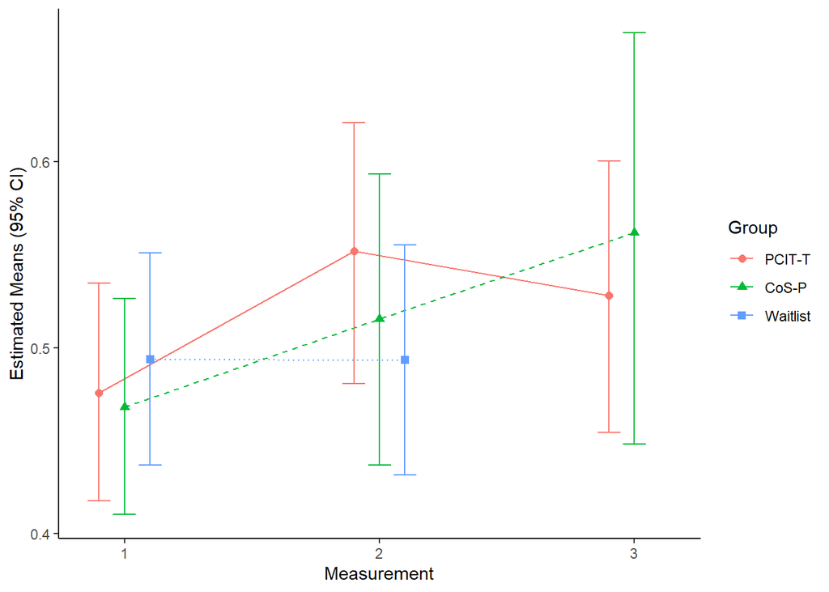

#### Hypothesis 1

We hypothesize that from baseline (‘T1’) to post-treatment/waitlist (‘T2’) there will be a gradient effect, whereby parent-child dyads who receive PCIT-T will show the greatest gains and parent-child dyads who receive no treatment will show the least gains. For the outcome, then, the null hypothesis is:

$H_0: \text {mean change}(\text{PCIT-T}) = \text {mean change}(\text{CoS-P}) = \text {mean change}(\text{Waitlist})$ $H_A: \text {mean change}(\text{PCIT-T}) > \text {mean change}(\text{CoS-P}) > \text {mean change}(\text{Waitlist})$

This is a joint hypothesis test.

First, confirming that the orderig of the means is as hypothesized:

```
## group = 1:
##  contrast odds.ratio    SE  df asymp.LCL asymp.UCL
##  2 / 1         1.357 0.185 Inf     0.986      1.87
##  3 / 1         1.232 0.177 Inf     0.880      1.73
##  3 / 2         0.908 0.141 Inf     0.632      1.31
##
## group = 2:
##  contrast odds.ratio    SE  df asymp.LCL asymp.UCL
##  2 / 1         1.210 0.176 Inf     0.861      1.70
##  3 / 1         1.459 0.323 Inf     0.867      2.45
##  3 / 2         1.205 0.279 Inf     0.701      2.07
##
## group = 3:
##  contrast odds.ratio    SE  df asymp.LCL asymp.UCL
##  2 / 1         0.999 0.106 Inf     0.780      1.28
##  3 / 1        nonEst    NA  NA        NA        NA
##  3 / 2        nonEst    NA  NA        NA        NA
##
## Confidence level used: 0.95
## Conf-level adjustment: tukey method for comparing a family of 3 estimates
## Intervals are back-transformed from the log odds ratio scale
```

Here, the odds of compliance 1.36 times the odds at time 2 than time 1 for PCIT-T. Or, there is a 36% increase in the odds of compliance at Time 2.

Now, to get the p-value associated with the joint hypothesis.

```r
## Specify contrast matrices
# Hyp1 is 1 df test
# could use alternative="less" ir alternative="greater" in glht
hyp1   <- matrix(c(0, 0,0, 0,0, -1,0,0 ),1)
# Hyp2 is 1 df test,
hyp2   <- matrix(c(0, 0,0, 0,1, 0,1,0 ),1)


# hypF is combined 2df test. Yes!
h<-rbind(hyp1,hyp2)
hypF <- as.matrix(h)
GlobalF <- glht(result3, linfct = hypF, test = Ftest())
GlobalF$linfct
```

```
##   (Intercept) group2 group3 time2 time3 group2:time2 group3:time2 group2:time3
## 1           0      0      0     0     0           -1            0            0
## 2           0      0      0     0     1            0            1            0
```

```r
summary(GlobalF, test = Ftest())
```

```
##
##   General Linear Hypotheses
##
## Linear Hypotheses:
##        Estimate
## 1 == 0  0.11448
## 2 == 0 -0.09755
##
## Global Test:
##        F DF1 DF2 Pr(>F)
## 1 0.2326   2 155 0.7927
```

```r
#also see this webpage for more on contrasts https://rcompanion.org/rcompanion/h_01.html
```

p>0.05 so this hypothesis is not supported.

#### Hypothesis 2

##### Change from T2-T3

There will be a gradient of size of change from T2 to T3 such that the change in the PCIT-T group > the change in the CoS-P group. This isn’t really a gradient; it’s just 1 hypothesis.

First, the change in PCITT and COSP from time 2 to time 3:

```
## group = 1:
##  time   prob     SE  df asymp.LCL asymp.UCL
##  1     0.476 0.0301 Inf     0.417     0.535
##  2     0.552 0.0360 Inf     0.481     0.621
##  3     0.528 0.0375 Inf     0.454     0.600
##
## group = 2:
##  time   prob     SE  df asymp.LCL asymp.UCL
##  1     0.468 0.0298 Inf     0.410     0.527
##  2     0.516 0.0403 Inf     0.437     0.594
##  3     0.562 0.0574 Inf     0.448     0.669
##
## group = 3:
##  time   prob     SE  df asymp.LCL asymp.UCL
##  1     0.494 0.0293 Inf     0.437     0.551
##  2     0.493 0.0317 Inf     0.432     0.555
##  3    nonEst     NA  NA        NA        NA
##
## Confidence level used: 0.95
## Intervals are back-transformed from the logit scale
```

```
## group = 1:
##  contrast odds.ratio    SE  df asymp.LCL asymp.UCL
##  2 / 1         1.357 0.185 Inf     0.986      1.87
##  3 / 1         1.232 0.177 Inf     0.880      1.73
##  3 / 2         0.908 0.141 Inf     0.632      1.31
##
## group = 2:
##  contrast odds.ratio    SE  df asymp.LCL asymp.UCL
##  2 / 1         1.210 0.176 Inf     0.861      1.70
##  3 / 1         1.459 0.323 Inf     0.867      2.45
##  3 / 2         1.205 0.279 Inf     0.701      2.07
##
## group = 3:
##  contrast odds.ratio    SE  df asymp.LCL asymp.UCL
##  2 / 1         0.999 0.106 Inf     0.780      1.28
##  3 / 1        nonEst    NA  NA        NA        NA
##  3 / 2        nonEst    NA  NA        NA        NA
##
## Confidence level used: 0.95
## Conf-level adjustment: tukey method for comparing a family of 3 estimates
## Intervals are back-transformed from the log odds ratio scale
```

```r
## Specify contrast matrices
# Hyp1 is 1 df test
# could use alternative="less" ir alternative="greater" in glht
hyp2   <- matrix(c(0, 0,0, 0,0, -1,0,1 ),1)
hyp2F <- glht(result3, linfct = hyp2)
summary(hyp2F)
```

```
##
##   Simultaneous Tests for General Linear Hypotheses
##
## Fit: glmer(formula = cbind(co, effcommands - co) ~ group + time +
##     group * time + (1 | id), data = p, family = binomial)
##
## Linear Hypotheses:
##        Estimate Std. Error z value Pr(>|z|)
## 1 == 0   0.2831     0.2784   1.017    0.309
## (Adjusted p values reported -- single-step method)
```

```r
s<-summary(hyp2F, test = Ftest())
#also see this webpage for more on contrasts https://rcompanion.org/rcompanion/h_01.html



## Extract pvaue for evidence / no evidence
evidence = ifelse(s$test$pvalue<0.05, "evidence", "no evidence")
```

Change in G1 from T2 to T3: 0.908

Change in G2 from T2 to T3: 1.205

##### Change from T1-T3

```
##
##   General Linear Hypotheses
##
## Linear Hypotheses:
##        Estimate
## 1 == 0   0.1686
##
## Global Test:
##        F DF1 DF2 Pr(>F)
## 1 0.4063   1 155 0.5248
```

Change in G1 from T1 to T3: 1.232

Change in G2 from T1 to T3: 1.459

p=0.5248. We have no evidence that the change from T1 to T3 is different for G1 and G2

#### Residuals

Before interpretation, we should examine model assumptions.

For this model (A generalized linear mixed model with binomial distribution and logit link, with random effect for individual), we have to use a different residual than for a linear mixed model. These are simulated residuals, using the DHARMa package in R (citation below).

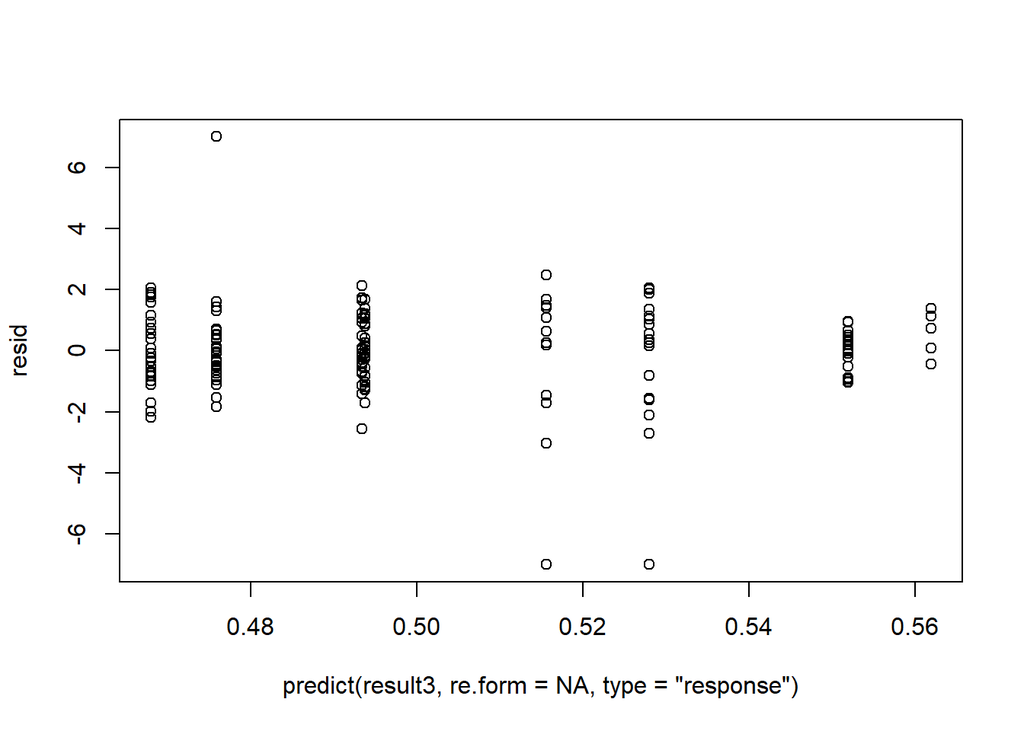

```r
library(DHARMa)

sim= simulateResiduals(result3)
resid = residuals(sim, quantileFunction = qnorm, outlierValues = c(-7,7))
plot(resid~predict(result3, re.form = NA,type="response"))
```

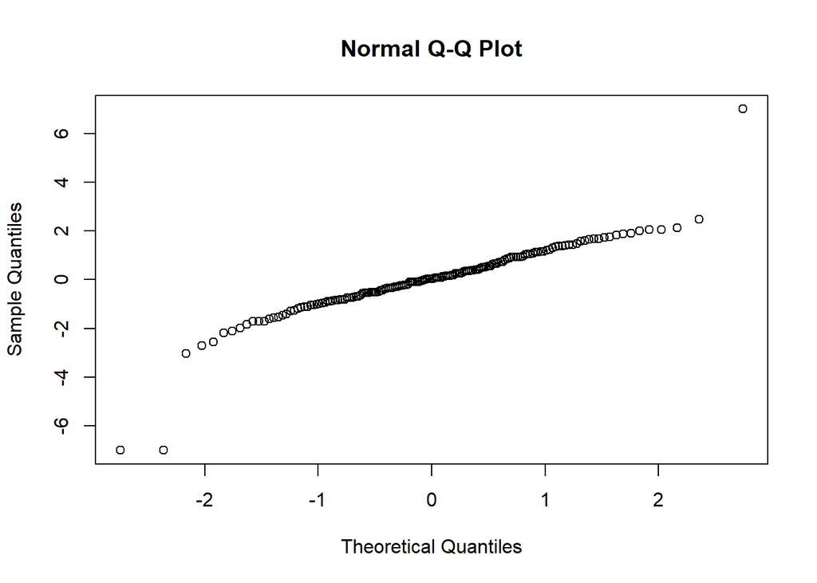

```r
qqnorm(resid)
```

```r
citation("DHARMa")
```

```
##
##
##   Florian Hartig (2022). DHARMa: Residual Diagnostics for Hierarchical
##   (Multi-Level / Mixed) Regression Models. R package version 0.4.5.
##   https://CRAN.R-project.org/package=DHARMa
##
## A BibTeX entry for LaTeX users is
##
##   @Manual{,
##     title = {DHARMa: Residual Diagnostics for Hierarchical (Multi-Level / Mixed)
## Regression Models},
##     author = {Florian Hartig},
##     year = {2022},
##     note = {R package version 0.4.5},
##     url = {https://CRAN.R-project.org/package=DHARMa},
##   }
```

There are a 3 observations that are not fit well by the model. These observations show very high or very low proportion of compliance to effective commands.

#### Sensitivity

Here is a quick sensitivity check excluding those 3 cases with very different proportions

```
## # A tibble: 9 x 7
##      id group t.x                       effcommands time  t.y                 co
##   <int> <fct> <chr>                           <int> <fct> <chr>            <int>
## 1    17 1     total_eff_commands_time_1          10 1     child_co_total_~     4
## 2    17 1     total_eff_commands_time_2          21 2     child_co_total_~    11
## 3    17 1     total_eff_commands_time_3          20 3     child_co_total_~     2
## 4    54 2     total_eff_commands_time_1          42 1     child_co_total_~    19
## 5    54 2     total_eff_commands_time_2          41 2     child_co_total_~     4
## 6    54 2     total_eff_commands_time_3          23 3     child_co_total_~    11
## 7    91 1     total_eff_commands_time_1          34 1     child_co_total_~    28
## 8    91 1     total_eff_commands_time_2          NA 2     child_co_total_~    NA
## 9    91 1     total_eff_commands_time_3          NA 3     child_co_total_~    NA
```

You can see that for id 91, the time 1 value is relatively high (28/34). For id 17 the time 3 value is low (2/20) and for id 54, the time 2 value is low (4/41). These observations will be removed and the model rerun.

```
## fixed-effect model matrix is rank deficient so dropping 1 column / coefficient
```

|  | Effect | npar | AIC | BIC | logLik | deviance | Chisq | Df | Pr(>Chisq) |
| --- | --- | --- | --- | --- | --- | --- | --- | --- | --- |
| result0 | Intercept | 2 | 939.5423 | 945.7052 | -467.7712 | 935.5423 | NA | NA | NA |
| result1 | Group | 4 | 943.4798 | 955.8054 | -467.7399 | 935.4798 | 0.0625763 | 2 | 0.9691963 |
| result2 | Time | 6 | 938.3749 | 956.8634 | -463.1875 | 926.3749 | 9.1048268 | 2 | 0.0105417 |
| result3 | Group*Time | 9 | 938.4691 | 966.2018 | -460.2346 | 920.4691 | 5.9058163 | 3 | 0.1162835 |

group*time effect is still not significant.

```
## Generalized linear mixed model fit by maximum likelihood (Laplace
##   Approximation) [glmerMod]
##  Family: binomial  ( logit )
## Formula: cbind(co, effcommands - co) ~ group + time + group * time + (1 |
##     id)
##    Data: p1
##
##      AIC      BIC   logLik deviance df.resid
##    938.5    966.2   -460.2    920.5      152
##
## Scaled residuals:
##      Min       1Q   Median       3Q      Max
## -2.88141 -0.65627 -0.08422  0.75025  2.48265
##
## Random effects:
##  Groups Name        Variance Std.Dev.
##  id     (Intercept) 0.2238   0.4731
## Number of obs: 161, groups:  id, 87
##
## Fixed effects:
##              Estimate Std. Error z value Pr(>|z|)
## (Intercept)  -0.14641    0.11759  -1.245   0.2131
## group2        0.01424    0.16403   0.087   0.9308
## group3        0.12016    0.16209   0.741   0.4585
## time2         0.31171    0.13607   2.291   0.0220 *
## time3         0.32177    0.14611   2.202   0.0277 *
## group2:time2  0.08816    0.20429   0.432   0.6661
## group3:time2 -0.31024    0.17213  -1.802   0.0715 .
## group2:time3 -0.01361    0.26305  -0.052   0.9587
## ---
## Signif. codes:  0 '***' 0.001 '**' 0.01 '*' 0.05 '.' 0.1 ' ' 1
##
## Correlation of Fixed Effects:
##             (Intr) group2 group3 time2  time3  grp2:2 grp3:2
## group2      -0.717
## group3      -0.726  0.520
## time2       -0.385  0.276  0.280
## time3       -0.371  0.266  0.269  0.374
## group2:tim2  0.256 -0.326 -0.186 -0.666 -0.249
## group3:tim2  0.305 -0.218 -0.378 -0.791 -0.296  0.526
## group2:tim3  0.207 -0.252 -0.151 -0.208 -0.556  0.272  0.167
## fit warnings:
## fixed-effect model matrix is rank deficient so dropping 1 column / coefficient
```

#### Estimated Means & Change

Adjusted p-value from Bonferroni correction.

##### Group mean at each timepoint

Estimated Mean Number of LP

| Time | Group | Mean | SE | LowerCL | UpperCL |
| --- | --- | --- | --- | --- | --- |
| 1 | 1 | 0.463 | 0.029 | 0.407 | 0.521 |
| 2 | 1 | 0.541 | 0.035 | 0.472 | 0.609 |
| 3 | 1 | 0.544 | 0.037 | 0.470 | 0.615 |
| 1 | 2 | 0.467 | 0.028 | 0.412 | 0.523 |
| 2 | 2 | 0.567 | 0.040 | 0.487 | 0.643 |
| 3 | 2 | 0.544 | 0.056 | 0.433 | 0.651 |
| 1 | 3 | 0.493 | 0.028 | 0.439 | 0.548 |
| 2 | 3 | 0.494 | 0.030 | 0.435 | 0.553 |
| 3 | 3 | NA | NA | NA | NA |

##### Group mean difference at each timepoint

Between-Group Differences

| Comparison | Time | Ratio | SE | z | p | adj p | Lower CL | Upper CL |
| --- | --- | --- | --- | --- | --- | --- | --- | --- |
| 1 / 2 | 1 | 0.986 | 0.162 | -0.087 | 0.996 | 1.000 | 0.671 | 1.448 |
| 1 / 3 | 1 | 0.887 | 0.144 | -0.741 | 0.739 | 1.000 | 0.607 | 1.297 |
| 2 / 3 | 1 | 0.899 | 0.144 | -0.663 | 0.785 | 1.000 | 0.619 | 1.308 |
| 1 / 2 | 2 | 0.903 | 0.195 | -0.473 | 0.884 | 1.000 | 0.544 | 1.499 |
| 1 / 3 | 2 | 1.209 | 0.226 | 1.019 | 0.565 | 0.925 | 0.781 | 1.872 |
| 2 / 3 | 2 | 1.340 | 0.273 | 1.434 | 0.323 | 0.455 | 0.831 | 2.161 |
| 1 / 2 | 3 | 0.999 | 0.272 | -0.002 | 1.000 | 1.000 | 0.527 | 1.893 |
| 1 / 3 | 3 | NA | NA | NA | NA | NA | NA | NA |
| 2 / 3 | 3 | NA | NA | NA | NA | NA | NA | NA |

* Effect size here is the ratio of means A value greater than 1 indicates a proportion change from the reference group.

##### Change within each group

Within-Group Change

| Change | Group | Ratio | SE | z | p | adj p | Lower CL | Upper CL |
| --- | --- | --- | --- | --- | --- | --- | --- | --- |
| 2 / 1 | 1 | 1.366 | 0.186 | 2.291 | 0.057 | 0.066 | 0.993 | 1.879 |
| 3 / 1 | 1 | 1.380 | 0.202 | 2.202 | 0.071 | 0.083 | 0.980 | 1.943 |
| 3 / 2 | 1 | 1.010 | 0.160 | 0.064 | 0.998 | 1.000 | 0.697 | 1.463 |
| 2 / 1 | 2 | 1.492 | 0.227 | 2.624 | 0.024 | 0.026 | 1.044 | 2.132 |
| 3 / 1 | 2 | 1.361 | 0.297 | 1.410 | 0.336 | 0.476 | 0.815 | 2.272 |
| 3 / 2 | 2 | 0.912 | 0.217 | -0.385 | 0.922 | 1.000 | 0.522 | 1.594 |
| 2 / 1 | 3 | 1.001 | 0.106 | 0.014 | 1.000 | 1.000 | 0.782 | 1.282 |
| 3 / 1 | 3 | NA | NA | NA | NA | NA | NA | NA |
| 3 / 2 | 3 | NA | NA | NA | NA | NA | NA | NA |

* Effect size here is the ratio of change. A value greater than 1 indicates a proportion change from the reference timepoint.

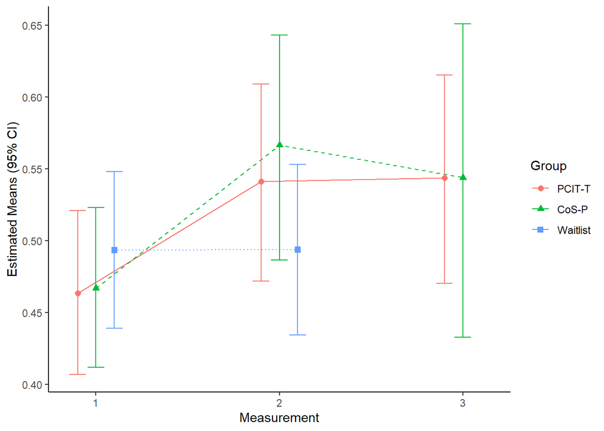

Takeaway: removing those relatively extreme values doesn’t change conclusions.

```r
rm(list = ls())
```